# Occupational Table Exploratory Data Analysis

# Summary

Stina sent two datasets. One is occupational data for all Canadian immigrants, from 1980 to 2016 (10 and 5 year increments), while the other is a series of archived web-only tables (prepared datasets) for the Haitian Canadian community specifically. I will explore the former here. I don’t want to resort to web-scraping for the latter. So I will try to gather the Haitian Canadian datasets that underlie the tables with an API in another notebook.

I tried to download the raw data, rather than the table data, for this dataset. Unfortunately, downloading 1gb+ failed multiple times. I will look into gathered the equivalent data with an API in the other notebook.

I was able to wrangle the table data into some sample visualizations without styling (below). It will be relatively easy now to put any of the table data into this form. Moreover, this kind of visualization is probably among the best for this table data.

## Data import

The csv file for the table that Stina linked had additional information that needed to be removed to be parsed correctly:

“Occupation - National Occupational Classification (NOC) 2016 (693A), Highest Certificate, Diploma or Degree (15), Admission Category and Applicant Type (31), Period of Immigration (7), Age (5A) and Sex (3) for the Immigrant Population Who Landed Between 1980 and 2016 Aged 15 Years and Over, in Private Households of Canada, Provinces and Territories, 2016 Census - 25% Sample Data”

## Different views with filtering

```r
# Top-level categories
imm_occ %>%
  filter(str_detect(code, "\\b[1-9]{1}\\b")) %>%
  select(c("code", "occupation"))
```

| code | occupation |
| --- | --- |
| 1 | Business, finance and administration occupations |
| 2 | Natural and applied sciences and related occupations |
| 3 | Health occupations |
| 4 | Occupations in education, law and social, community and government services |
| 5 | Occupations in art, culture, recreation and sport |
| 6 | Sales and service occupations |
| 7 | Trades, transport and equipment operators and related occupations |
| 8 | Natural resources, agriculture and related production occupations |
| 9 | Occupations in manufacturing and utilities |
| [1] | Excludes census data for one or more incompletely enumerated Indian reserves or Indian settlements. |

[output cut: 7 more lines]

```r
# EX: "Occupations in manufacturing and utilities"
imm_occ %>%
  filter(str_detect(code, "^9[1-9]$")) %>%
  select(c("code", "occupation"))
```

| code | occupation |
| --- | --- |
| 92 | Processing, manufacturing and utilities supervisors and central control operators |
| 94 | Processing and manufacturing machine operators and related production workers |
| 95 | Assemblers in manufacturing |
| 96 | Labourers in processing, manufacturing and utilities |

```r
# EX: "Processing, manufacturing and utilities supervisors and central control operators"
imm_occ %>%
  filter(str_detect(code, "^92[1-9]$")) %>%
  select(c("code", "occupation"))
```

| code | occupation |
| --- | --- |
| 921 | Supervisors, processing and manufacturing occupations |
| 922 | Supervisors, assembly and fabrication |
| 923 | Central control and process operators in processing and manufacturing |
| 924 | Utilities equipment operators and controllers |

```r
imm_trans <- imm_occ %>%
  filter(str_detect(code, "751")) %>%
  select(matches("\\d"))
```

## Demo Visualization

Work in transportation over time among new immigrants to Canada.

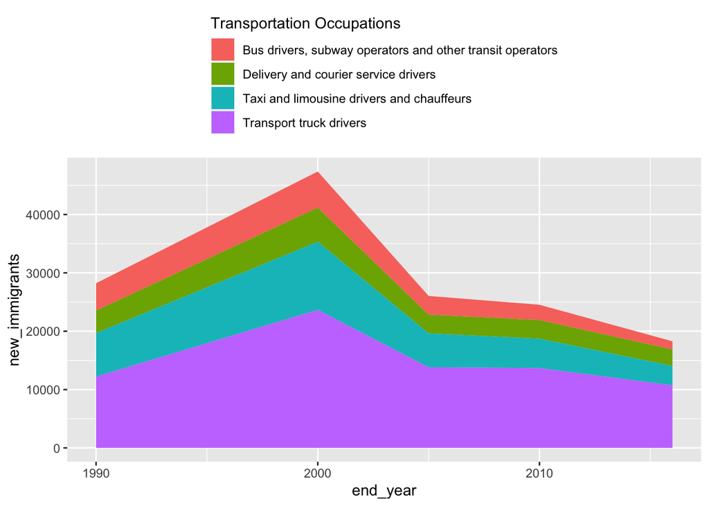

```r
# get transport occupations per year
imm_trans <- imm_occ %>%
  filter(str_detect(code, "751"))

imm_trans[-1,] %>% # remove total transport occupations row
  select(-"total")  %>% # remove total years immigration column
  pivot_longer(!c("code", "occupation"),
               names_to = "years",
               values_to = "new_immigrants") %>%
  separate(years,
           into = c("start_year", "end_year"),
           sep = "_",
           convert = TRUE) %>%
  ggplot(aes(x = end_year, y = new_immigrants, fill = occupation)) +
  geom_area() +
  theme(legend.position="top") +
  guides(fill = guide_legend(title = "Transportation Occupations",
                             direction = "vertical"))
```

Work in transportation over time among new immigrants to Canada, percentages.

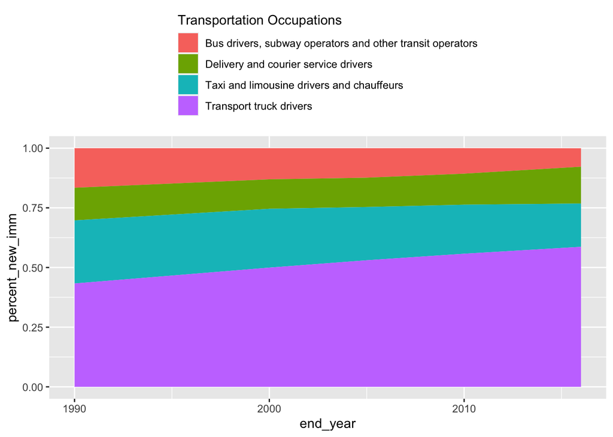

```r
imm_rel <- bind_cols(imm_trans[c("code", "occupation", "total")], imm_trans %>%
            transmute(across(matches("\\d"), ~ ./ .[1])))

imm_rel[-1,] %>% # remove total transport occupations row
  select(-"total")  %>% # remove total years immigration column
  pivot_longer(!c("code", "occupation"),
               names_to = "years",
               values_to = "percent_new_imm") %>%
  separate(years,
           into = c("start_year", "end_year"),
           sep = "_",
           convert = TRUE) %>%
  ggplot(aes(x = end_year, y = percent_new_imm, fill = occupation)) +
  geom_area() +
  theme(legend.position="top") +
  guides(fill = guide_legend(title = "Transportation Occupations",
                             direction = "vertical"))
```